# Un Modello Statistico per Prevedere il Peso dei Neonati

```r
lev_no_outlier[lev_no_outlier>soglia_no_outlier]
```

```
         13          15          34          36          61          67
0.005650688 0.008360559 0.006945282 0.007513606 0.006193129 0.006542776
         89         101         106         119         131         134
0.012827227 0.013788530 0.015695059 0.005929380 0.007917769 0.007739072
        151         155         161         190         204         206
0.010912760 0.009564225 0.022829946 0.005634219 0.014723234 0.010370177
        220         294         304         305         310         312
0.008139474 0.005922522 0.006203188 0.006018479 0.029063188 0.035974435
        317         328         378         383         440         442
0.006601402 0.007592699 0.016667948 0.006603600 0.005618442 0.007744597
        445         471         492         513         516         582
0.008196935 0.008829708 0.018823139 0.006408422 0.013171759 0.012366732
        587         592         600         638         656         666
0.008948815 0.006631718 0.005801140 0.006812846 0.006310365 0.008045328
        684         697         702         706         729         748
0.009095228 0.006046027 0.005697818 0.005801280 0.008074943 0.013910728
        750         757         765         805         828         895
0.009308438 0.008240495 0.006591164 0.034137280 0.007206578 0.006204960
        928         946         947         956         958         964
0.129002619 0.007641894 0.013753465 0.009181528 0.006234030 0.007270593
        985         988         991        1008        1014        1067
0.007178322 0.006451693 0.007244774 0.005641964 0.017325282 0.008510378
       1091        1106        1130        1166        1181        1188
0.009618447 0.006334149 0.032111612 0.005653896 0.006013074 0.008659195
       1200        1219        1222        1238        1248        1273
0.005796291 0.030713790 0.005698584 0.006161086 0.026626578 0.008695964
       1283        1291        1293        1311        1321        1323
0.007269058 0.006570567 0.006275922 0.009677182 0.009481115 0.007085760
       1356        1357        1370        1385        1400        1411
0.005862317 0.007544790 0.005628865 0.012807418 0.007414676 0.008132879
       1428        1429        1450        1505        1513        1553
0.018635931 0.026580555 0.015115244 0.013349714 0.008569932 0.008579297
       1556        1573        1593        1610        1619        1628
0.006009530 0.006650793 0.006131518 0.010208496 0.063091198 0.006984601
       1639        1686        1701        1712        1718        1727
0.007513617 0.009512148 0.019817230 0.007205553 0.007021416 0.013411696
       1767        1780        1781        1809        1827        1868
0.006069687 0.087359079 0.017109065 0.008760192 0.006249870 0.005605924
       1920        1962        1977        2040        2046        2086
0.006568449 0.005853719 0.007673187 0.015972534 0.006040009 0.013199282
       2089        2114        2115        2120        2140        2146
0.009271246 0.040472293 0.013656240 0.028431660 0.007269114 0.005953653
       2148        2149        2157        2175        2200        2216
0.008029893 0.020575806 0.006145479 0.055387454 0.011882539 0.009604388
       2221        2224        2225        2244        2257        2307
0.021644293 0.005880366 0.006422097 0.006949852 0.009515121 0.026178932
       2317        2359        2391        2408        2422        2437
0.007717439 0.010085056 0.011834289 0.010579179 0.021552224 0.100352340
       2452        2458        2471        2478
0.053998209 0.008617719 0.020972493 0.007077514
```

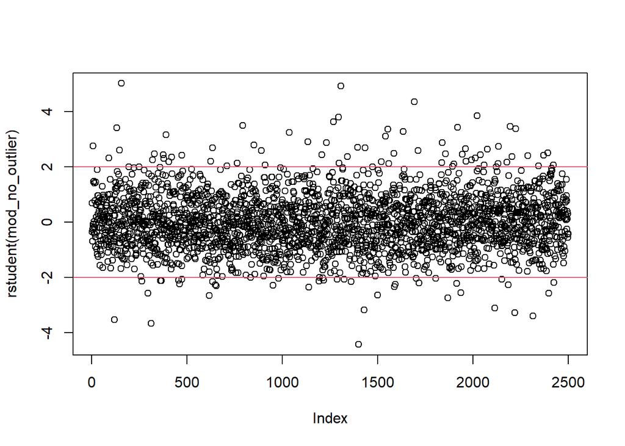

```r
plot(rstudent(mod_no_outlier))
abline(h = c(-2,2), col = 2)
```

```r
car::outlierTest(mod_no_outlier)
```

```
      rstudent unadjusted p-value Bonferroni p
155   5.022700         5.4557e-07    0.0013634
1306  4.921696         9.1401e-07    0.0022841
1399 -4.431888         9.7455e-06    0.0243540
1694  4.357310         1.3701e-05    0.0342380
```

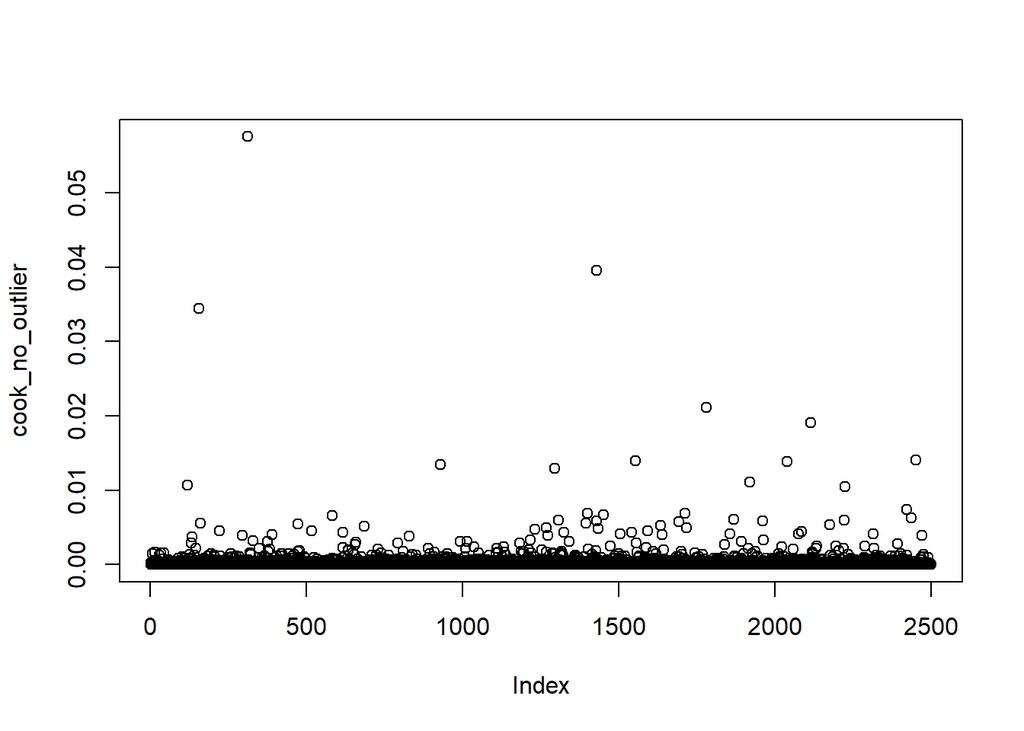

```r
cook_no_outlier <- cooks.distance(mod_no_outlier)
plot(cook_no_outlier)
```

```r
max(cook_no_outlier)
```

```
[1] 0.0575372
```

Le considerazioni sono le seguenti:

- l’eliminazione dell’osservazione 1551 ha comportato un aumento notevole del p-value relativo al test sull’omoschedasticità dei residui, tuttavia non sufficiente a superare il valore di 0.05, quindi continuiamo a rifiutare l’ipotesi nulla di omoschedasticità.
- per le altre assunzioni del modello lineare non ci sono considerazioni rilevanti da fare.
- per quanto concerne i valori influenti, sono aumentati i leverage (da 142 a 148) e sono diminuiti gli outliers (da 5 a 4). Tuttavia, calcolando la distanza di cook non risultano esserci nuovi valori influenti.
- confrontando il valore dell’R quadro aggiustato per lo stesso modello con e senza il valore influente nel dataframe, possiamo notare che è aumentato da 0.7363 a 0.7413, quindi la rimozione del dato è giustificata.

In soldoni, l’eliminazione dell’osservazione sembra essere stata corretta, giustificata dal fatto che ci sono stati una serie di miglioramenti nel modello.

#### 6. Quanto ti sembra buono il modello per fare previsioni?

Date le conclusioni del punto precedente (assunzioni violate sia per quanto riguarda l’omoschedasticità che per la distribuzione Normale dei residui), nonostante una buona percentuale di varianza spiegata (R-quadro aggiustato di oltre il 73%), i valori stimati del modello dovrebbero essere presi con cautela.

L’eteroschedasticità dei residui implica infatti che la varianza dei residui differisce nell’intervallo di valori delle variabili indipendenti. In altre parole essa può portare a stime più o meno distorte. Mentre il fatto che i residui non seguano una distribuzione normale può causare problemi nell’interpretazione della significatività statistica dei parametri di regressione.

In linea generale, sarebbe aupicabile l’utilizzo di modelli di regressione diversi, come i GLM, che sono in grado di cattuare in maniera più adeguata distribuzioni degli errori diverse da quella Normale.

#### 7. Fai la tua migliore previsione per il peso di una neonata, considerato che la madre è alla terza gravidanza e partorirà alla 39esima settimana. Niente misure dall’ecografia.

Creiamo un nuovo modello senza le variabili *Lunghezza* e *Cranio*:

```r
mod7 <- lm(Peso ~ + N.gravidanze + Gestazione + Sesso,
           data = neonati)
summary(mod7)
```

```
Call:
lm(formula = Peso ~ +N.gravidanze + Gestazione + Sesso, data = neonati)

Residuals:
     Min       1Q   Median       3Q      Max
-1494.15  -272.82   -14.43   267.31  1892.39

Coefficients:
              Estimate Std. Error t value Pr(>|t|)
(Intercept)  -3136.835    175.410 -17.883  < 2e-16 ***
N.gravidanze    23.395      6.509   3.595 0.000331 ***
Gestazione     162.025      4.499  36.014  < 2e-16 ***
SessoM         165.144     16.729   9.872  < 2e-16 ***
---
Signif. codes:  0 '***' 0.001 '**' 0.01 '*' 0.05 '.' 0.1 ' ' 1

Residual standard error: 414.2 on 2496 degrees of freedom
Multiple R-squared:  0.3784,    Adjusted R-squared:  0.3777
F-statistic: 506.5 on 3 and 2496 DF,  p-value: < 2.2e-16
```

Di seguito la funzione `predict()` per fare la previsione:

```r
predict(mod7, newdata = data.frame(N.gravidanze=3, Gestazione = 39, Sesso = "F"))
```

```
       1
3252.311
```

Prevediamo quindi che il peso di una neonata avente questi parametri fissati sia di 3252.3 grammi.

#### 8. Cerca di creare qualche rappresentazione grafica che aiuti a visualizzare il modello. .Se è il caso semplifica quest’ultimo!

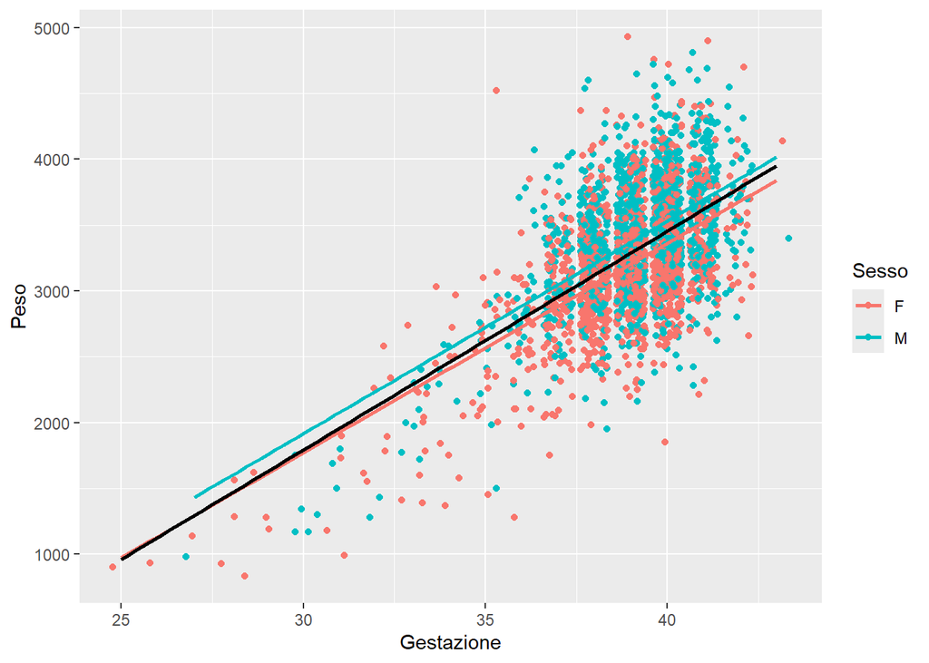

```r
ggplot(neonati)+
  geom_point(aes(x = Gestazione,
                 y = Peso,
                 col = Sesso), position = "jitter")+
  geom_smooth(aes(x = Gestazione,
                  y = Peso,
                  col = Sesso), se = F, method = "lm")+
  geom_smooth(aes(x = Gestazione,
                  y = Peso), col = "black", se = F, method = "lm")
```